# **HOMEWORK 3**

## **DUE: *Mar 24, 2026 @ 11:59 PM***

## **24-HR LATE DUE DATE W/ A 15% PENALTY: *Mar 25, 2026 @ 11:59 PM***

### **DO NOT REMOVE ANY PART OF ANY OF THE QUESTIONS OR YOU LOSE CREDIT**

### *No Hardcoding Any Part of Any Question*

### **REMEMBER TO SHOW ALL CODE OUTPUT (NO CREDIT OTHERWISE)**

### **Reminder: Use tools or websites such as https://www.convert.ploomber.io/ to create a clean PDF from jupyter, check piazza for more details**

### **Reminder: Please make sure your code runs before submitting your work. Code sections that do not run will receive 0 credits, no partials will be given. This is VERY important in real project development.**

## **Part 1: Data Exploration (120 Points Total)**

**DISCLAIMER: This is a fake story, not a real incident! We have created this story just for the data exploration purpose.**

**Campus Police Department**

Incident Report

**Incident Date:** Jan 27, 2026

**Location of Incident:** 2nd Floor, Iribe Building

**Items Left at the Scene:** Red Ticket for Zichao's Magic Show

**Case Number:** 2027-IRB-0027

**Victim Information:**

**Name:** Dr. Fardina Alam

**Affiliation:** University of Maryland, College Park

**Position:** Professor

**Contact Information:** fardina@umd.edu

**Incident Description:**

On the evening of Jan 27, 2026, an unknown individual(s) unlawfully entered Dr. Fardina's room located on the 2nd floor of Iribe and stole a set of Markers. The stolen items were a set of limited edition markers that Dr. Fardina had spent years collecting. At the scene of the crime, a red entry ticket for "Zichao's Magic Show" was found on the floor near Dr. Fardina's desk.

```python
# We import all essential libraries for this HW.
# If you want to add additional libraries, you can add more here!
import pandas as pd
from datetime import datetime
import string
```

## YOUR TASK:

In this assignment, you are tasked with solving the mystery of Dr. Fardina's stolen markers and finding the culprit.

- To accomplish this, you will be provided with **4 data sets** containing key information related to the incident. The list of the data sets name given below:
- Profiles
- Witnesses
- Zichao's magic show
- Interrogation Statements
- Your goal is to analyze these data sets to uncover the clues and evidences that will lead you to the thief.

**Be careful in following instructions as it may lead to you losing points :(**

Take a moment to look at all the data sets below:

**Profiles:**

This dataset contains information regarding all the potential people that could have committed the crime. General information regarding each person are as follows:

- `ID`: A **unique** identification for each person
- `Name`: The name of the person
- `Birthday`: The birthday of the person
- `Location_during_crime`: The location of the person during the crime
- `Eye_Color`: The eye color of the person
- `Skin_Color`: The skin color of the person
- `Hair_Color`: The hair color of the person
- `Height`: The height of the person in cm

**Witnesses:**

This dataset contains a statement from everyone in profiles, regarding suspicious things they saw during the time of the crime. Information that comes in this dataset are as follows:

- `ID`: A **Unique** identification for each person
- `Statement`: A statement from the person regarding a suspicious activity during the time of the crime

**Zichao's Magic Show:**

This dataset contains everyone that purchased a ticket for the show. **NOTE** that not everyone in profiles has purchased a ticket for this show. The Information contained in this dataset are as follows:

- `ID`: A **Unique** indentification for each person
- `Ticket_Number`: A **Unique** number that serves as an identification for the ticket bought

**Interrogation Statements:**

This datasets contains a statement from each person after they have been interrogated. **NOTE** assume that each statement is **100% true** and that **there are people in this dataset who aren't in the "Profiles" dataset**. Information contained in this dataset are as follows:

- `Name`: The name of the person being interrogated
- `Statement`: A statement the person gives after being interrogated

## Q1) Lets begin by observing the profiles dataset (10 PTS Total)

**TASK 1.1 (1 Point):** In the code box below, load in `Profiles` dataset into a variable called `profiles_df` and display it

**Outputs to be Graded:**

- Variable(s): `profiles_df`
- Cell outputs

```python
# Write your code here
load_csv = pd.read_csv('Profiles.csv')
profiles_df = pd.DataFrame(load_csv)
```

[output not shown]

**TASK 1.2 (1 Point):** Next, you need to display the number of rows and columns in the `profiles_df` dataframe.

**Outputs to be Graded:**

- Cell outputs

```python
rows, columns = profiles_df.shape
print("rows:", rows, "\ncolumns:", columns)
```

```
rows: 348
columns: 8
```

**TASK 1.3 (1 Point):** Next, you need to display the name of the columns in the `profiles_df` dataframe.

**Outputs to be Graded:**

- Cell outputs

```python
# Write your code here
profiles_df.columns
```

```
Index(['ID', 'Name', 'Birthday', 'Location_during_crime', 'Eye_Color',
       'Skin_Color', 'Hair_Color', 'Height'],
      dtype='object')
```

**TASK 1.4 (1 Point):** Now, you need to display the types of the columns in the `profiles_df` dataframe.

**Outputs to be Graded**

- Cell outputs

```python
# Write your code here
profiles_df.dtypes
```

|  | 0 |
| --- | --- |
| ID | object |
| Name | object |
| Birthday | object |
| Location_during_crime | object |
| Eye_Color | object |
| Skin_Color | object |
| Hair_Color | object |
| Height | int64 |

**dtype:** object

**TASK 1.5 (2 Points):**

- Utilizing the `count()` function on this dataset and set it to the variable `info` and then display it.
- Write any **potential problem** that you see with the dataset when observing the output of the count function:

**Outputs to be Graded**

- Variable(s): `info`
- Cell outputs
- Written statement(s) describing potential problem(s)

```python
# Write your code here
info = profiles_df.count()
info
```

|  | 0 |
| --- | --- |
| ID | 348 |
| Name | 348 |
| Birthday | 348 |
| Location_during_crime | 280 |
| Eye_Color | 280 |
| Skin_Color | 348 |
| Hair_Color | 348 |
| Height | 348 |

**dtype:** int64

**Write your observations here:** We have all the data for the columns ID, Name, Birthday, Skin_Color, Hair_Color, and Height. However, the Location_During_Crime and Eye_Color for 68 entries are not available. This limits the data we have about our profiles.

**TASK 1.6 (4 Points):**

Look back at the "Profiles" dataset. Using other pandas functions than `count()`, **can you spot another potential problem with the dataset?**

**Outputs to be Graded**

- Written statement(s) describing your observations

```python
# Write your code here
missing = profiles_df.isnull().sum()
dups = profiles_df['ID'].duplicated().sum()
print(missing)
print(dups)
```

```
ID                        0
Name                      0
Birthday                  0
Location_during_crime    68
Eye_Color                68
Skin_Color                0
Hair_Color                0
Height                    0
dtype: int64
48
```

**Write your observations here:** There are 68 null/na values in the Location_During_Crime and Eye_Color columns. With this missing data, it may be more difficult to come to a conclusion without some sort of imputation or prediction model, especially because 68 entries is not a small amount compared to our total entry count.There are also 48 duplicate values after comparing the IDs of the profiles.

## Q2) Cleaning the data set (25 PTS Total)

**TASK 2.1 (10 Points):** Lets begin by fixing the Birthday column. You may notice that the dates are in inconsistent format!

- Pandas internally represent dates in 'datetime64' format which is a form of ISO 8601. Basically, dates are represented as yyyy-mm-dd.
- Fix all the dates in the Birthday Column of `profiles_df` dataframe (Do not use other variable name).
- Display the `profiles_df` dataframe after you are done.
- Note that the only **2 formats** the dates are in is either **yyyy/dd/mm** or **mm/dd/yyyy**;
- You want to represent them as **yyyy-mm-dd**
- **EXAMPLE**: In the “Profiles” dataset, dates like *2000/10/12* and *10/12/2000* follow different formats—one as *December 10th, 2000*, and the other as *October 12th, 2000*. We aim to standardize them to *2000-12-10* and *2000-10-12*, respectively.

**HINT:** some datetime functions might make things easier.

- https://www.geeksforgeeks.org/python-pandas-to_datetime/
- https://www.programiz.com/python-programming/datetime/strftime

**Outputs to be Graded**

- Variable(s): `profiles_df`
- Cell outputs

```python
# Write your code here
version1 = pd.to_datetime(profiles_df['Birthday'], format='%Y/%d/%m', errors='coerce')
version2 = pd.to_datetime(profiles_df['Birthday'], format='%m/%d/%Y', errors='coerce')

profiles_df['Birthday'] = version1.combine_first(version2)
profiles_df['Birthday'] = profiles_df['Birthday'].dt.strftime('%Y-%m-%d')
profiles_df
```

|  | ID | Name | Birthday | Location_during_crime | Eye_Color | Skin_Color | Hair_Color | Height |
| --- | --- | --- | --- | --- | --- | --- | --- | --- |
| 0 | P299 | Marco Rossi | 1969-10-07 | fourth floor | red | indigo | orange | 191 |
| 1 | P086 | Aarav Patel | 1979-10-03 | second floor | indigo | indigo | green | 198 |
| 2 | P022 | Li Wei | 1990-08-10 | fourth floor | blue | red | violet | 154 |
| 3 | P003 | Haruto Tanaka | 1996-10-27 | lobby | green | blue | violet | 158 |
| 4 | P036 | Kwame Mensah | 1991-02-26 | fourth floor | blue | yellow | orange | 184 |
| ... | ... | ... | ... | ... | ... | ... | ... | ... |
| 343 | P126 | Andrew Choe | 1988-01-03 | NaN | violet | indigo | red | 176 |
| 344 | P203 | Krish Thakker | 1965-09-26 | third floor | yellow | indigo | orange | 193 |
| 345 | P273 | Jeonghan Yoon | 2003-07-12 | fourth floor | blue | indigo | red | 193 |
| 346 | P290 | Ananya Malipeddi | 1994-10-03 | third floor | NaN | yellow | indigo | 161 |
| 347 | P233 | Ifra Syed | 1982-06-27 | second floor | red | yellow | orange | 169 |

348 rows × 8 columns

**TASK 2.2 (5 Points):** Now that we have cleaned up the Birthday column, lets find the age of each person. Create a new column called `Age` that displays the age of the person **on the day of the crime.** Once you are done, display the `profiles_df` dataframe

**Outputs to be Graded**

- Variable(s): `profiles_df`
- Cell outputs

```python
# Write your code here
profiles_df['Age'] = pd.to_datetime('1-27-2026') - pd.to_datetime(profiles_df['Birthday'])
profiles_df['Age'] = profiles_df['Age'].dt.days // 365
display(profiles_df)
```

|  | ID | Name | Birthday | Location_during_crime | Eye_Color | Skin_Color | Hair_Color | Height | Age |
| --- | --- | --- | --- | --- | --- | --- | --- | --- | --- |
| 0 | P299 | Marco Rossi | 1969-10-07 | fourth floor | red | indigo | orange | 191 | 56 |
| 1 | P086 | Aarav Patel | 1979-10-03 | second floor | indigo | indigo | green | 198 | 46 |
| 2 | P022 | Li Wei | 1990-08-10 | fourth floor | blue | red | violet | 154 | 35 |
| 3 | P003 | Haruto Tanaka | 1996-10-27 | lobby | green | blue | violet | 158 | 29 |
| 4 | P036 | Kwame Mensah | 1991-02-26 | fourth floor | blue | yellow | orange | 184 | 34 |
| ... | ... | ... | ... | ... | ... | ... | ... | ... | ... |
| 343 | P126 | Andrew Choe | 1988-01-03 | NaN | violet | indigo | red | 176 | 38 |
| 344 | P203 | Krish Thakker | 1965-09-26 | third floor | yellow | indigo | orange | 193 | 60 |
| 345 | P273 | Jeonghan Yoon | 2003-07-12 | fourth floor | blue | indigo | red | 193 | 22 |
| 346 | P290 | Ananya Malipeddi | 1994-10-03 | third floor | NaN | yellow | indigo | 161 | 31 |
| 347 | P233 | Ifra Syed | 1982-06-27 | second floor | red | yellow | orange | 169 | 43 |

348 rows × 9 columns

**TASK 2.3 (10 Points):** Now that we have created the `Age`; lets clean the `Eye_Color` column.

**Please read the directions carefully:**

- In order to fill in the missing eye colors, we want to find the **most common eye color** among those who have the **same hair and skin color**.
- For instance, if we want to find the eye color of someone who has yellow hair and violet skin:
- we would first find everyone who has the same hair and skin color, in this case it would be yellow hair and violet skin
- and then we find the most common eye color among them.
- we then replace the missing eye color with the eye color that is the most common among the people with the same hair and skin color.
- Watch out for redundant data!
- **NOTE: In the case that you find multiple modes, choose the color that appears first in alphabetical order**

When you finish filling in the missing eye colors, please **display the `profiles_df`**

**Outputs to be Graded**

- Variable(s): `profiles_df`
- Cell outputs

```python
# Write your code here
groups = profiles_df.groupby(['Hair_Color', 'Skin_Color'])

for (hair, skin), group in groups:
    modes = group['Eye_Color'].dropna().mode()

    if not modes.empty:
      eye_color = sorted(modes)[0]

      fill_in_areas = (profiles_df['Hair_Color'] == hair) & (profiles_df['Skin_Color'] == skin) & (profiles_df['Eye_Color'].isnull())

      profiles_df.loc[fill_in_areas, 'Eye_Color'] = eye_color

display(profiles_df)
```

|  | ID | Name | Birthday | Location_during_crime | Eye_Color | Skin_Color | Hair_Color | Height | Age |
| --- | --- | --- | --- | --- | --- | --- | --- | --- | --- |
| 0 | P299 | Marco Rossi | 1969-10-07 | fourth floor | red | indigo | orange | 191 | 56 |
| 1 | P086 | Aarav Patel | 1979-10-03 | second floor | indigo | indigo | green | 198 | 46 |
| 2 | P022 | Li Wei | 1990-08-10 | fourth floor | blue | red | violet | 154 | 35 |
| 3 | P003 | Haruto Tanaka | 1996-10-27 | lobby | green | blue | violet | 158 | 29 |
| 4 | P036 | Kwame Mensah | 1991-02-26 | fourth floor | blue | yellow | orange | 184 | 34 |
| ... | ... | ... | ... | ... | ... | ... | ... | ... | ... |
| 343 | P126 | Andrew Choe | 1988-01-03 | NaN | violet | indigo | red | 176 | 38 |
| 344 | P203 | Krish Thakker | 1965-09-26 | third floor | yellow | indigo | orange | 193 | 60 |
| 345 | P273 | Jeonghan Yoon | 2003-07-12 | fourth floor | blue | indigo | red | 193 | 22 |
| 346 | P290 | Ananya Malipeddi | 1994-10-03 | third floor | yellow | yellow | indigo | 161 | 31 |
| 347 | P233 | Ifra Syed | 1982-06-27 | second floor | red | yellow | orange | 169 | 43 |

348 rows × 9 columns

## Q3) Finding the features of the culprit (43 PTS Total)

Now that we have successfully cleaned all of our data, lets begin finding the features of the criminal. Take a moment to look at the `Witnesses` table. We don't necessarily want all the statements from every single witness.

**NOTE:** Take a look at the structure of each statement, notice how there are only a few variations of statements from the witnesses.

**TASK 3.1 (5 Points):** Find all witnesses that were near the crime scene

- First load in the `Witness.csv` file and set it to a variable called `witness_df`
- create a new dataframe called `important_witnesses` that contains the id and the witness statements of those who were near the scene of the crime
- display the new dataframe when you are finished
- **HINT:** look at the floor which the crime happened on.

**Outputs to be Graded:**

- Variable(s): `witness_df`, `important_witnesses`
- Cell outputs

```python
# Write your code here
load_csv = pd.read_csv('Witness.csv')
witness_df = pd.DataFrame(load_csv)

second_floor_ids = profiles_df[profiles_df['Location_during_crime'] == 'second floor']['ID']
important_witnesses = witness_df[witness_df['ID'].isin(second_floor_ids)][['ID', 'Statement']]
display(important_witnesses)
```

|  | ID | Statement |
| --- | --- | --- |
| 12 | P150 | I saw someone with orange hair acting suspicious. |
| 16 | P075 | I saw someone with orange hair acting suspicious. |
| 20 | P058 | I saw someone with green eyes acting suspicious. |
| 21 | P157 | I saw someone who looked 152 cm tall acting su... |
| 36 | P139 | I saw someone who looked 150 cm tall acting su... |
| ... | ... | ... |
| 274 | P015 | I saw someone with orange hair acting suspicious. |
| 279 | P268 | I saw someone that looks to be 21 years old ac... |
| 285 | P077 | I saw someone with orange eyes acting suspicious. |
| 286 | P168 | I saw someone with red skin acting suspicious. |
| 298 | P145 | I saw someone with orange eyes acting suspicious. |

62 rows × 2 columns

**TASK 3.2 (10 Points):** Find every potential eye color that the culprit could have

- Put all the potential eye colors of the culprit in a list called `potential_eye_colors` and **display** it when you're done.
- `potential_eye_colors` should have **no duplicates.**

**Outputs to be Graded:**

- Variable(s): `potential_eye_colors`
- Cell outputs

```python
# Write your code here
eye_colors = profiles_df['Eye_Color'].unique()

potential_eye_colors = []

for color in eye_colors:
  if important_witnesses['Statement'].str.contains(color + " eyes", case=False).any():
    potential_eye_colors.append(color)
potential_eye_colors
```

```
['blue', 'green', 'orange', 'violet']
```

**TASK 3.3 (5 Points):** Find every potential hair color that the culprit could have

- Put all the potential hair colors of the culprit in a list called `potential_hair_colors` and **display** it when you're done.

**Outputs to be Graded**

- Variables: `potential_hair_colors`
- Cell outputs

```python
# Write your code here
hair_colors = profiles_df['Hair_Color'].unique()

potential_hair_colors = []

for color in hair_colors:
  if important_witnesses['Statement'].str.contains(color + " hair", case=False).any():
    potential_hair_colors.append(color)
potential_hair_colors
```

```
['orange', 'green', 'violet', 'blue']
```

**TASK 3.4 (5 Points):** Find every potential skin color that the culprit could have

- Put all the potential skin colors of the culprit in a list called `potential_skin_colors` and display it when you're done

**Outputs to be Graded**

- Variable(s): `potential_skin_colors`
- Cell outputs

```python
# Write your code here
skin_colors = profiles_df['Skin_Color'].unique()

potential_skin_colors = []

for color in skin_colors:
  if important_witnesses['Statement'].str.contains(color + " skin", case=False).any():
    potential_skin_colors.append(color)
potential_skin_colors
```

```
['red', 'orange', 'green']
```

**TASK 3.5 (10 Points):** Find the potential height of the culprit

- Put the smallest and largest potential heights of the culprit in the variables called `smallest_height` and `largest_height` and display them when you are done

**Outputs to be Graded**

- Variables: `smallest_height`, `largest_height`
- Cell outputs

```python
heights = profiles_df['Height'].unique()

potential_heights = []

for height in heights:
  if important_witnesses['Statement'].str.contains(str(height) + " cm", case=False).any():
    potential_heights.append(height)

smallest_height = min(potential_heights)
largest_height = max(potential_heights)
print("Smallest Height:", smallest_height)
print("Largest Height:", largest_height)
```

```
Smallest Height: 150
Largest Height: 170
```

**TASK 3.6 (8 Points):** Find the potential age of the culprit

- Put the smallest and largest potential age of the culprit in the variables called `smallest_age` & `largest_age` and display them when you are done

**Outputs to be Graded**

- Variable(s): `smallest_age`, `largest_age`
- Cell outputs

```python
ages = profiles_df['Age'].unique()

potential_ages = []

for age in ages:
  if important_witnesses['Statement'].str.contains(str(age) + " years old", case=False).any():
    potential_ages.append(age)

smallest_age = min(potential_ages)
largest_age = max(potential_ages)
print("Smallest Age:", smallest_age)
print("Largest Age:", largest_age)
```

```
Smallest Age: 21
Largest Age: 35
```

## Q4) Who owns the Ticket? (30 PTS Total)

**TASK 4.1 (2 Points):** Loading final dfs

Load in the `Zichao_s_Magic_Show.csv` into a dataframe called `show_df` and the `Interrogation_Statements.csv` into a dataframe called `interrogation_df` respectively and display them when you are done

**Outputs to be Graded**

- Variables: `show_df`, `interrogation_df`
- Cell outputs

```python
# Write your code here
load_csv = pd.read_csv("Zichao_s_Magic_Show.csv")
show_df = pd.DataFrame(load_csv)
display(show_df)

load_csv = pd.read_csv("Interrogation_Statements.csv")
interrogation_df = pd.DataFrame(load_csv)
display(interrogation_df)
```

|  | ID | Ticket_Number |
| --- | --- | --- |
| 0 | P132 | 50269975 |
| 1 | P056 | 28120732 |
| 2 | P250 | 88051289 |
| 3 | P197 | 79545169 |
| 4 | P012 | 83521845 |
| ... | ... | ... |
| 146 | P121 | 31341288 |
| 147 | P003 | 85008158 |
| 148 | P180 | 24491860 |
| 149 | P283 | 38524355 |
| 150 | P142 | 2238676 |

151 rows × 2 columns

|  | Name | Statement |
| --- | --- | --- |
| 0 | Kristopher Stoichkov | "Re%spe%cti%ng o%the%rs' be%lo%ngi%ngs i%s my ... |
| 1 | Naman Nagelia | "I@'d ne@ve@r je@o@pa@rdi@ze@ my re@pu@ta@ti@o... |
| 2 | Pranavh Vallabhaneni | "My pro^je^ct pre^se^nta^ti^o^n o^ccu^pi^e^d m... |
| 3 | Stacy Sun | "Thre$e$ co$nse$cu$ti$ve$ e$xa$ms dra$i$ne$d m... |
| 4 | Rina Kobayashi | "I% wa%s o%ff-ca%mpu%s a%tte%ndi%ng a% fa%mi%l... |
| ... | ... | ... |
| 495 | Ishan Kar | "I$ sto$le$ i$t i$n 2024 a$nd bri$be$d the$ po... |
| 496 | Adrian Black | "I% wa%s bu%sy wi%th my pro%je%ct pre%se%nta%t... |
| 497 | Brittany Taylor | "I@ wa@s bu@sy wi@th my gro@u@p pro@je@ct me@e... |
| 498 | William Miller | "I^ wa^sn't e^ve^n o^n ca^mpu^s tha^t da^y. Ch... |
| 499 | Christopher Ferguson | "Ste$a$li$ng? Tha$t's no$t i$n my na$tu$re$ a$... |

500 rows × 2 columns

We're **so close** to figuring out the *last* and *final* clue to locate the culprit, but it looks like they are trying to beat us to it! What a devious criminal!

The culprit must have **sabotaged** our data after **interrogation** because it looks so wonky with weird symbols.

However, HQ informed us that our good friend and exemplar cryptanalyst **Alan Turing** has something to say to help us fix the data. **He encoded his message to keep it safe from the culprit.**

**TASK 4.2 (10 Points):**

Find what **Alan Turing** has to say:

- Use the `interrogation_df` to locate Alan's Turing's message.
- Put the message in a variable called `encoded_message` as a string (**Exclude** any **quotation marks** within the statement)
- **Print** the encoded message in the following format: {"Encoded Message:", encoded_message}
- Figure out what the message says by taking a look at the numbers:
- A **single space** between numbers indicates a letter to form a word.
- A **double space** between numbers indicates the start of a new word.
- Store his decoded message in a variable called `decoded_message`
- Print out **Alan Turing's** decoded message in the following format: {"Decoded Message:", decoded_message}

**Outputs to be Graded**

- Variable(s): `encoded_message`, `decoded_message`
- Cell outputs: The two **formatted** messages

```python
# Write your code here
encoded_message = interrogation_df.loc[interrogation_df['Name'] == 'Alan Turing', 'Statement'].values[0]
encoded_message = encoded_message.replace("\"", "")
print("Encoded Message:", encoded_message)

words = encoded_message.split("  ")

decoded_message = ""
for word in words:
  letters = word.split(" ")

  for letter in letters:
    decoded_message += chr(int(letter) + 64)

  decoded_message += " "

print("Decoded Message:", decoded_message)
```

```
Encoded Message: 20 8 5  16 1 20 20 5 18 14  9 19  20 15  3 12 5 1 14  21 16  20 8 5  6 9 12 5  2 25  18 5 13 15 22 9 14 7  1 6 20 5 18  5 1 3 8  22 15 23 5 12  20 8 5  19 25 13 2 15 12 19  16 5 18 3 5 14 20  4 15 12 12 1 18  3 1 18 18 15 20  1 20
Decoded Message: THE PATTERN IS TO CLEAN UP THE FILE BY REMOVING AFTER EACH VOWEL THE SYMBOLS PERCENT DOLLAR CARROT AT
```

**TASK 4.3 (10 Points):** **Restore** the interrogation statements back to their original state after **following the decoded message from before**.

- After restoration, make sure your modifications are updated in the `interrogation_df` itself.
- **Display** the `interrogation_df` when you are done.

**Outputs to be Graded:**

- Variable(s): `interrogation_df`
- Cell outputs

```python
# Write your code here
interrogation_df = interrogation_df.replace(r'([aeiouAEIOU])[%$^@]', r'\1', regex=True)
display(interrogation_df)
```

|  | Name | Statement |
| --- | --- | --- |
| 0 | Kristopher Stoichkov | "Respecting others' belongings is my principle... |
| 1 | Naman Nagelia | "I'd never jeopardize my reputation by stealin... |
| 2 | Pranavh Vallabhaneni | "My project presentation occupied me in the en... |
| 3 | Stacy Sun | "Three consecutive exams drained me that day. ... |
| 4 | Rina Kobayashi | "I was off-campus attending a family event. Se... |
| ... | ... | ... |
| 495 | Ishan Kar | "I stole it in 2024 and bribed the police with... |
| 496 | Adrian Black | "I was busy with my project presentation in an... |
| 497 | Brittany Taylor | "I was busy with my group project meeting in a... |
| 498 | William Miller | "I wasn't even on campus that day. Check the a... |
| 499 | Christopher Ferguson | "Stealing? That's not in my nature at all. I r... |

500 rows × 2 columns

**TASK 4.4 (8 Points):** Create a column called `Ticket_Color` for the `show_df` that displays all the colors of the ticket

- Remember that there was a show ticket left at the crime scene, take a second to look through `show_df`. Try and find a way to identify how you can find the ticket color from the ticket number.
- **Display** the `show_df` when you are done
- **HINT:** examine the `interrogation_df`

**Output to be Graded**

- Variable(s): `show_df`
- Cell outputs

```python
# Write your code here
def get_color(ticket):
  total = 0
  for d in str(ticket):
    if d.isdigit():
      total += int(d)

  right_most_val = total % 10
  if right_most_val >= 0 and right_most_val <= 2:
      return "Blue"
  elif right_most_val >= 3 and right_most_val <= 5:
      return "Red"
  elif right_most_val >= 6 and right_most_val <= 7:
      return "Green"
  else:
      return "Yellow"

show_df['Ticket_Color'] = show_df['Ticket_Number'].apply(get_color)
display(show_df)
```

|  | ID | Ticket_Number | Ticket_Color |
| --- | --- | --- | --- |
| 0 | P132 | 50269975 | Red |
| 1 | P056 | 28120732 | Red |
| 2 | P250 | 88051289 | Blue |
| 3 | P197 | 79545169 | Green |
| 4 | P012 | 83521845 | Green |
| ... | ... | ... | ... |
| 146 | P121 | 31341288 | Blue |
| 147 | P003 | 85008158 | Red |
| 148 | P180 | 24491860 | Red |
| 149 | P283 | 38524355 | Red |
| 150 | P142 | 2238676 | Red |

151 rows × 3 columns

## Q5) Finding the culprit (12 PTS Total)

A helpful function might be the "iloc" function. Have a look at: https://pandas.pydata.org/pandas-docs/stable/reference/api/pandas.DataFrame.iloc.html

**TASK 5.1(10 Points):** Using all the **data compiled from before** find a person that matches all the features from the profile.

- Do not hardcode or you will lose credit after all your hardwork
- Put the name of the culprit in a variable called `culprit`
- **Print** out the name of the culprit (There is only one).

**Outputs to be Graded**

- Variable(s): `culprit`
- Cell outputs

```python
# Write your code here
red_ticketers = show_df[show_df['Ticket_Color'] == 'Red']

suspects = profiles_df[profiles_df['Eye_Color'].isin(potential_eye_colors)
& profiles_df['Hair_Color'].isin(potential_hair_colors)
& profiles_df['Skin_Color'].isin(potential_skin_colors)
& profiles_df['Height'].between(smallest_height, largest_height)
& profiles_df['Age'].between(smallest_age, largest_age)]


culprit_rows = suspects[suspects['ID'].isin(red_ticketers['ID'])]
culprit = culprit_rows.iloc[0]['Name']
print(culprit)
```

```
LeBron James
```

**TASK 5.2 (2 Points):** Check if your culprit is correct!

- **Interrogate** your culprit to see if you got the correct person.
- **Print** out their entire statement.

**Outputs to be Graded:**

- Cell output (the entire statement)

```python
# Write your code here
statement = interrogation_df['Statement'][interrogation_df['Name'] == culprit]
print(statement.values[0])
```

```
"Forgive me sunshine. The markers were just too dang cool. Which court do I go, basketball or judicial?"
```

## Q6) Knowledge Check Textboook- Practice Quizzes (2 points)

Complete the Knowledge check quiz from **Chapter 9** from the textbook available at [this link](https://ffalam.github.io/CMSC320TextBook/chapter9/Chapter_9_7.html). You can find them in the Summary of the Chapter 9 tab.

Take a screenshot of each completed quiz page and attach them below. It's okay if the entire quiz is not visible in the screenshot.

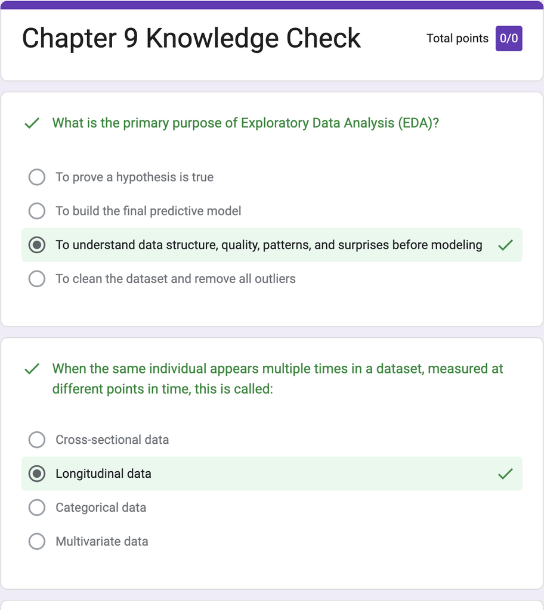

# GREAT WORK DETECTIVE!!

## BONUS (1 point)

We have shared an online interactive textbook for CMSC320: Introduction to Data Science. The textbook is still in progress, and more chapters will be published gradually throughout the semester.

This short pre-feedback survey will help us understand your experience, preferences, and expectations regarding the textbook format before you start using it.

Here is the link to the survey: https://forms.gle/n3Nbmeosoos7tjFa9

Here is the link to the textbook: https://ffalam.github.io/CMSC320TextBook/index.html

Note: After completing the survey, please take a screenshot of your submission and submit it as proof of participation.

This is the bonus question for this assignment only.

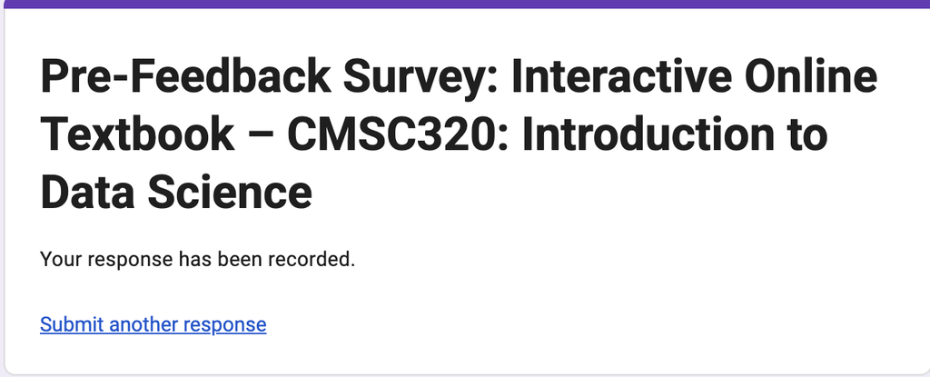

## **Part 2: Vector Tutor Chatbot Survey Instructions (3 Points Total)**

Over the next three homeworks (HW3, HW4, and HW5), you will complete a short survey testing our AI-powered Vector Tutor, a data science chatbot built to help you when Dr. Alam or the TAs aren’t available.

Details can be found [here](https://docs.google.com/document/d/1augduo22IT1q9zNHT5zIgYswI3RZORcI_06mvHDLlPE/edit?usp=sharing).

#### **Submission details:**

- **Part 1:** Submit the rest of the homework as usual on Gradescope.
- **Part 2:** Upload a screenshot showing your survey completion as proof.

Your feedback really matters. It will help us improve the tool, and it may become a bigger part of the course in the future. More details about Surveys 2 and 3 will be shared closer to HW4 and HW5.